# Acoustic enrichment and mass larval release amplify coral settlement success

### Impacts of acoustic and larval restoration

```r
#

summary <- counts_df |>
  dplyr::group_by(treatment) |>
  dplyr::summarise(
    n = sum(!is.na(total_settlers)),
    mean = mean(total_settlers, na.rm = TRUE),
    sd = stats::sd(total_settlers, na.rm = TRUE),
    se = sd / sqrt(n),
    tcrit = stats::qt(0.975, df = pmax(n - 1, 1)),
    ci_low = mean - tcrit * se,
    ci_high = mean + tcrit * se,
    .groups = "drop"
  )
```

```r
# options(brms.backend = "rstan")
#
# fit_base <- brm(
#   total_settlers ~  treatment + speed + hard_coral + sar +
#     s(site_x, site_y, k = 23) + #(n-1)
#      (1 | site),
#   data = counts_df,
#   family = negbinomial(),
#   prior = c(
#     prior(normal(0, 2), class = "b"),
#     prior(exponential(1), class = "sd"),
#     prior(exponential(1), class = "sds"),
#     prior(exponential(1), class = "shape")
#   ),
#   chains = 4, cores = 4, iter = 4000,
#   control = list(adapt_delta = 0.999, max_treedepth = 15),
#   save_pars = save_pars(all = TRUE),
#   silent = 0, refresh = 0
# )
#
# saveRDS(fit_base, "/Users/rof011/acoustics/data/fit_base.rds")

fit_base <- readRDS(here("data", "fit_base.rds"))

library(brms)
library(bayestestR)

# 1) Directional "p-value" using hypothesis()
#    One-sided: H1: treatmentacoustic > 0
hypothesis(fit_base, "treatmentacoustic > 0")
hypothesis(fit_base, "treatmentlarval > 0")
hypothesis(fit_base, "treatmentlarvalacoustic > 0")

# 2) Using p_direction (pd)
pd_acoustic <- pd(fit_base, parameter = "treatment")
pd_acoustic


# 3) ROPE  – keep for effect size / practical null:
rope(fit_base, parameter = "treatment", range = c(-0.05, 0.05))
# interpret as "how much of posterior is practically near 0", not as p
```

[output not shown]

```r
plot_means <- counts_df %>%
  group_by(treatment, site) %>%
  summarise(total_settlers = mean(total_settlers, na.rm = TRUE), .groups = "drop")

t_ci <- plot_means %>%
  group_by(treatment) %>%
  summarise(
    n_plots = n(),
    mean    = mean(total_settlers),
    sd      = sd(total_settlers),
    se      = sd / sqrt(n_plots),
    tcrit   = qt(0.975, df = n_plots - 1),
    low95   = mean - tcrit * se,
    hi95    = mean + tcrit * se,
    .groups = "drop"
  ) %>%
  as.data.frame() %>%
  select(treatment, mean, low95, hi95)

t_ci
```

```
       treatment       mean       low95        hi95
1        control  0.4047619  0.01190829   0.7976155
2       acoustic  2.0604396  0.60526212   3.5156170
3         larval 31.4404762 10.72064107  52.1603113
4 larvalacoustic 69.6666667  7.18057122 132.1527621
```

[figure not shown]

```r
library(dplyr)
library(purrr)
library(tidyr)



fit_base <- readRDS("/Users/rof011/acoustics/data/fit_base.rds")

# ---- population-level newdata (match fit_base covariates) ----
cov_means <- counts_df %>%
  summarise(
    speed     = mean(speed,    na.rm = TRUE),
    hard_coral  = mean(hard_coral, na.rm = TRUE),
    sar = mean(sar, na.rm=TRUE),
    site_x        = mean(site_x,        na.rm = TRUE),
    site_y        = mean(site_y,        na.rm = TRUE)
  )

pop_nd <- tibble(
  treatment    = factor(c("control","acoustic","larval","larvalacoustic"),
                        levels = levels(counts_df$treatment)),
  speed    = cov_means$speed[1],
  hard_coral = cov_means$hard_coral[1],
  sar = cov_means$sar[1],
  site_x        = cov_means$site_x[1],
  site_y        = cov_means$site_y[1]
)

# ---- posterior expected counts per treatment (population-level; no REs) ----
epred_pop <- add_epred_draws(pop_nd, fit_base, re_formula = NA) %>%
  ungroup() %>%
  select(.draw, treatment, .epred)

# ---- expected counts summary ----
pop_sum <- epred_pop %>%
  group_by(treatment) %>%
  mean_qi(.epred, .width = 0.95) %>%
  ungroup()

# ---- contrasts (ratios) ------------------------------------------------------
contr_draws <- epred_pop %>%
  pivot_wider(names_from = treatment, values_from = .epred) %>%
  transmute(
    .draw,
    `larvalacoustic / larval` = larvalacoustic / larval,
    `larvalacoustic / control` = larvalacoustic / control,
    `larval / control`        = larval / control,
    `acoustic / control`      = acoustic / control
  ) %>%
  pivot_longer(-.draw, names_to = "contrast", values_to = "ratio") %>%
  filter(is.finite(ratio), ratio > 0) %>%
  mutate(
    contrast = str_replace_all(contrast, " / ", "/"),
    contrast = factor(contrast,
                      levels = c("larvalacoustic/larval",
                                 "larvalacoustic/control",
                                 "larval/control",
                                 "acoustic/control"))
  )

contr_summary <- contr_draws %>%
  group_by(contrast) %>%
  summarise(
    median  = median(ratio, na.rm = TRUE),
    low95   = quantile(ratio, 0.025, na.rm = TRUE),
    hi95    = quantile(ratio, 0.975, na.rm = TRUE),
    Pr_gt1  = mean(ratio > 1, na.rm = TRUE),
    .groups = "drop"
  ) %>%
  mutate(
    medianlabel = paste0("x", round(median, 1)),
    pr_label    = sprintf("Pr(>1)=%.2f", Pr_gt1)
  )


inla_dat_df_site <- counts_df |> group_by(treatment, site) |> summarise(settlers=mean(exp(log_settlers)))

# ---- raw-scale increment draws ----------------------------------------------
raw_inc_draws <- epred_pop %>%
  tidyr::pivot_wider(names_from = treatment, values_from = .epred) %>%
  dplyr::transmute(
    .draw,
    C  = control,
    L  = larval,
    A  = acoustic,
    LA = larvalacoustic,
    inc_L   = L  - C,
    inc_A   = A  - C,
    inc_LA  = LA - C,
    inc_add = inc_L + inc_A,               # additive expectation (raw scale)
    d_inc   = inc_LA - inc_add,            # difference (0 = raw-additive)
    OE_inc  = inc_LA / pmax(inc_add, 1e-9) # ratio (1 = raw-additive); guard small denom
  )

# ---- medians for label positions --------------------------------------------
median_df <- raw_inc_draws %>%
  dplyr::select(
    `observed increment (LA - C)`            = inc_LA,
    `additive increment ((L - C) + (A - C))` = inc_add
  ) %>%
  tidyr::pivot_longer(
    cols      = dplyr::everything(),
    names_to  = "contrast",
    values_to = "value"
  ) %>%
  dplyr::filter(value > 0) %>%   # keep only positive (log10 scale)
  dplyr::group_by(contrast) %>%
  dplyr::summarise(
    median  = median(value, na.rm = TRUE),
    .groups = "drop"
  )

# ---- plot: expected counts (log scale) ----
expectedcounts <- ggplot() +
  #  geom_jitter(
  #   data = inla_dat_df_site,
  #   aes(x = fct_inorder(treatment), y = settlers, color = treatment),
  #   width = 0.1,
  #   alpha = 0.15,
  #   size = 0.8,
  #   show.legend = FALSE
  # ) +
   ggdist::stat_slab(
    data = epred_pop,
    aes(x = fct_inorder(treatment), y = .epred, fill = treatment),
    side = "right",
    color="black",
    , linewidth = 0.15,
    orientation = "vertical",
    show.legend=FALSE,
    alpha = 0.35,
    color = NA) +
  # geom_point(data = inla_dat_df_site,
  #               aes(x = fct_inorder(treatment), y = settlers), shape=21) +
     geom_errorbar(data = pop_sum,
                aes(x = fct_inorder(treatment), y = .epred, ymin = .lower, ymax = .upper),
                width = 0, linewidth = 0.25) +
  geom_point(data = pop_sum,
             aes(x = fct_inorder(treatment), y = .epred, fill = treatment),
             size = 2, shape = 21, show.legend = FALSE) +
  scale_y_log10() +
  labs(x = "", y = "Predicted settlers (population-level)") +
  theme_bw() +
  scale_fill_manual(values=scales::brewer_pal(palette = "YlGnBu")(4)[1:4])
#  scale_fill_manual(values=c("coral", "yellow", "mediumturquoise", "deepskyblue"), name="")
#coralcolors::scale_fill_coral(palette = "acropora2")
library(scales)
# ---- plot: density ridges of contrasts (log-x) with Pr(ratio>1) annotations ----
densityridges <- ggplot() +
  geom_vline(xintercept = 1, linetype = 2, linewidth = 0.4, alpha = 0.7) +
  ggridges::stat_density_ridges(
    data = contr_draws,
    aes(x = ratio, y = contrast, fill = contrast),
    geom = "density_ridges", show.legend = FALSE, quantile_lines = TRUE, linetype = "dotted",
    rel_min_height = 0.0005, alpha = 0.45, scale = 0.7, linewidth = 0.25
  ) +
  ggridges::stat_density_ridges(
    data = contr_draws,
    aes(x = ratio, y = contrast), fill = NA,
    geom = "density_ridges", show.legend = FALSE, quantile_lines = FALSE,
    rel_min_height = 0.0005, alpha = 0.75, scale = 0.7, linewidth = 0.25
  ) +
  geom_text(data = contr_summary,
            aes(x = median, y = contrast, label = medianlabel),
            size = 2.5, nudge_y = 0.25) +
  geom_text(data = contr_summary,
            aes(x = hi95, y = contrast, label = pr_label),
            size = 2.4, nudge_y = -0.1) +
   ggplot2::scale_x_continuous(
    trans = "log10",
    limits = c(0.1, 500),
    breaks = c(1, 10, 100),
    labels = c("1", "10", "100")
  ) +
 scale_y_discrete(
    expand = expansion(mult = c(0.1, 0.4))  # adds internal padding below lowest ridge
  ) +
  labs(x = "Expected settlers ratio (log scale)", y = "Treatment contrasts") +
  theme_bw() +

  ggplot2::theme(
    panel.grid.minor = ggplot2::element_blank(),
    #panel.grid.major.x = ggplot2::element_blank(),
    axis.ticks.x = ggplot2::element_blank(),
    axis.text.x  = ggplot2::element_blank(),
    axis.title.x = ggplot2::element_blank(),
    legend.position = "none",
    plot.title = ggplot2::element_blank()
  ) +  scale_fill_manual(values=rev(brewer_pal(palette = "YlGnBu")(5)[2:5]))
  #coralcolors::scale_fill_coral("acropora2")

# ---- assemble with panel tags ----


main_res <- ggplot(
  data = counts_df |>
    dplyr::group_by(site, treatment) |>
    dplyr::summarise(counts = mean(total_settlers), .groups = "drop"),
  aes(treatment, counts)
) +
  theme_bw() +
  geom_violin(
    aes(fill = treatment),
    draw_quantiles = c(0.5),
    adjust = 1.5,
    trim = FALSE,
    alpha = 0.3,
    linewidth = 0.5,
    show.legend = FALSE
  ) +
  stat_summary(
    fun.data = function(x) {
      qs <- quantile(x, probs = c(0.1, 0.9), na.rm = TRUE)
      data.frame(
        ymin   = min(x, na.rm = TRUE),
        lower  = qs[1],
        middle = NA_real_,
        upper  = qs[2],
        ymax   = max(x, na.rm = TRUE)
      )
    },
    geom = "boxplot",
    show.legend = FALSE,
    width = 0.2,
    alpha = 0.5
  ) +
  geom_line(
    aes(group = site),
    show.legend = FALSE,
    position = position_jitter(width = 0.15, seed = 101),
    linewidth = 0.1,
    alpha = 0.4
  ) +
  geom_point(
    aes(group = site, fill = treatment),
    show.legend = FALSE,
    position = position_jitter(width = 0.15, seed = 101),
    size = 2,
    alpha = 0.4
  ) +
  scale_y_log10(
    labels = scales::label_number(accuracy = 1, big.mark = ",")
  ) +
  ylab("Settler count") +
  scale_x_discrete(labels = c("Control", "Larvae", "Acoustic", "Larvae + Acoustic")) +
  scale_fill_manual(values = scales::brewer_pal(palette = "YlGnBu")(4)[1:4])


ridge_a <- ggplot2::ggplot() +

  # Overlapping density ridges at the same y
  ggridges::geom_density_ridges(
    data = raw_inc_draws |>
      dplyr::select(
        .draw,
        `observed increment (LA − C)` = inc_LA,
        `additive increment ((L − C) + (A − C))` = inc_add
      ) |>
      tidyr::pivot_longer(-.draw, names_to = "contrast", values_to = "value") |>
      dplyr::filter(value > 0),
    ggplot2::aes(x = value, y = 0, color= contrast, fill = contrast),
    alpha = 0.5,
    scale = 1.2,
    linewidth=0.25,
    rel_min_height = 0.001,
    show.legend = FALSE,
    quantile_lines = TRUE,
    quantiles = 0.5,
    quantile_line_type = "solid",
    quantile_line_size = 1.0,
    quantile_line_color = "black"
  ) +

  # Median text labels
  ggplot2::geom_text(
    data = median_df,
    ggplot2::aes(x = median, y = 0.25, label = paste0("median = ", round(median, 1)), color = contrast),
    angle = 90,
    vjust = -0.4,
    hjust = 0,
    size = 3,
    show.legend = FALSE
  ) +
   ggplot2::scale_x_continuous(
    trans = "log10",
    limits = c(0.1, 500),
    breaks = c(1, 10, 100),
    labels = c("1", "10", "100")
  ) +
  ggplot2::scale_y_continuous(NULL, breaks = NULL) +
  ggplot2::labs(
    x = "Increment (log10 scale)",
    y = NULL,
    #title = "Observed vs additive increment distributions (same y)"
  ) +
  ggplot2::scale_fill_manual(
    values = c(
      "observed increment (LA − C)"            = "skyblue",
      "additive increment ((L − C) + (A − C))" = "white"
    )
  ) +
  ggplot2::scale_color_manual(
    values = c(
      "observed increment (LA − C)"            = "black",
      "additive increment ((L − C) + (A − C))" = "red"
    )
  ) +

  ggnewscale::new_scale_color() +
ggplot2::geom_vline(
  xintercept = 0,
  linetype   = 2,
  linewidth  = 0.4,
  alpha      = 0.7,
  color      = "grey30"
) +
  ggplot2::theme_bw() +
  ggplot2::theme(
    panel.grid.minor = ggplot2::element_blank(),
    legend.title     = ggplot2::element_blank(),
    legend.position  = "top"
  )

mainfig <- main_res /
           densityridges /
           ridge_a +
  plot_layout(heights = c(4, 4, 2)) +     # proportional heights 40/40/20
  plot_annotation(tag_levels = "a") &
  theme(
    plot.tag = element_text(face = "bold", size = 12),
    plot.tag.position = c(0.01, 0.99)
  )
mainfig
```

```r
ggsave(plot=mainfig, device = cairo_pdf,
       width=6, height=8, filename="/Users/rof011/Acoustics/Figures/Fig3.pdf")
```

## Extended Figures

### Extended Data Fig. 1 Sound

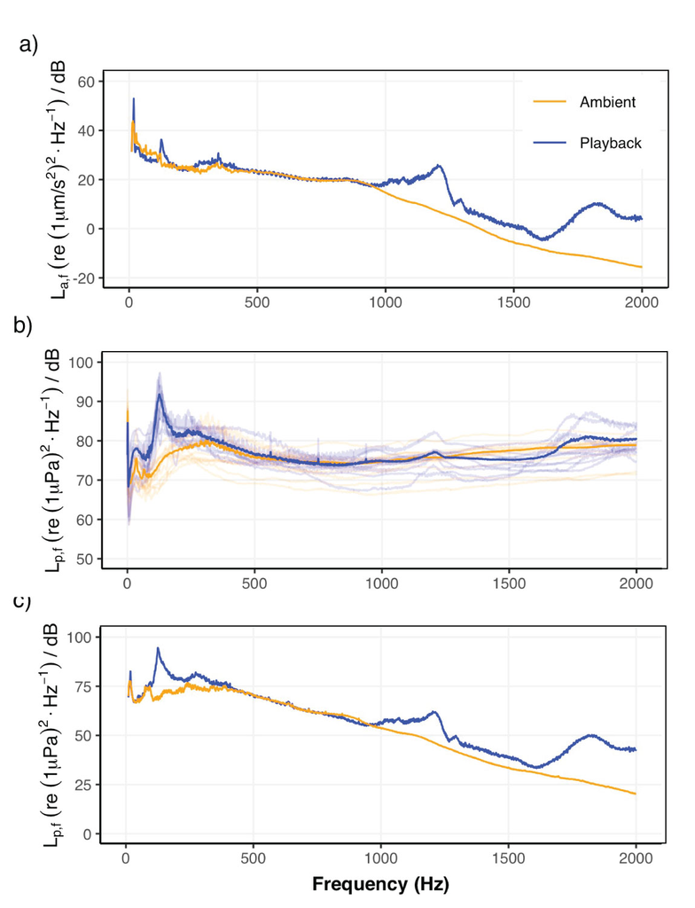

### Extended Data Fig. 2 Posterior estimates from the negative binomial hierarchical model

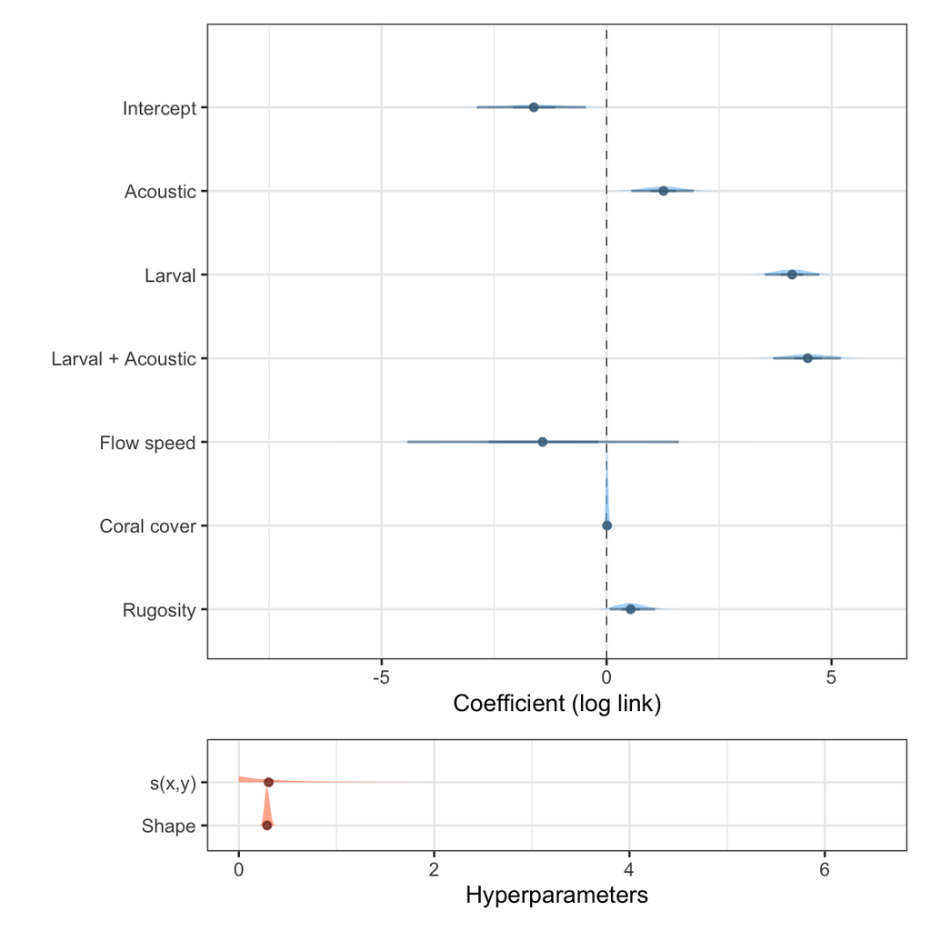

```r
library(posterior)
library(dplyr)
library(tidyr)
library(forcats)
library(ggplot2)
library(tidybayes)
library(stringr)
library(dplyr)
library(tidyr)
library(stringr)
library(forcats)
library(ggplot2)
library(patchwork)
library(tidybayes)
library(posterior)
draws <- posterior::as_draws_df(fit_base)
nms   <- names(draws)

# ----------------------------
# Fixed effects (+ smooth basis)
# ----------------------------
fix_cols <- grep("^(b_|bs_)", nms, value = TRUE)

p_fixed <- draws %>%
  select(all_of(fix_cols)) %>%
  pivot_longer(everything(), names_to = "term_raw", values_to = "value") %>%
  mutate(
    term = term_raw |>
      str_remove("^b_") |>
      str_remove("^bs_") |>
      str_replace("^sx_lony_lat_1$", "s(x_lon,y_lat)[1]") |>
      str_replace("^sx_lony_lat_2$", "s(x_lon,y_lat)[2]") |>
      str_replace("^speed$", "Flow speed") |>
      str_replace("^sar$", "Rugosity") |>
      str_replace("^hard_coral$", "Coral cover") |>
      str_replace("^treatmentacoustic$", "Acoustic") |>
      str_replace("^treatmentlarval$", "Larval") |>
      str_replace("^treatmentlarvalacoustic$", "Larval + Acoustic")
  ) %>%
  filter(!term_raw %in% c("bs_ssite_xsite_y_1", "bs_ssite_xsite_y_2")) |>
  ggplot(aes(y = fct_rev(fct_inorder(term)), x = value)) +
  geom_vline(xintercept = 0, linetype = 2, linewidth = 0.2) +
  stat_halfeye(.width = c(.90, .50), point_interval = "median_qi", linewidth=0.8, size=1.2,
               color = "skyblue4", fill = "skyblue2", alpha = 0.6) +
  labs(x = "Coefficient (log link)", y = "") +
  theme_bw()

# ----------------------------
# Hyperparameters: include sds + shape
# ----------------------------
hyper_cols <- unique(c(grep("^sds_", nms, value = TRUE), "shape"))

p_opt <- draws %>%
  select(all_of(hyper_cols)) %>%
  pivot_longer(everything(), names_to = "term_raw", values_to = "value") %>%
  mutate(
    term = term_raw |>
      str_replace("^sds_", "") |>
      str_replace("^sx_lony_lat_1$", "s(x_lon,y_lat)") |>
      str_replace("^sx_lony_lat_2$", "s(x_lon,y_lat)") |>
      str_replace("^ssite_xsite_y_1$", "s(x,y)") |>
      str_replace("^ssite_xsite_y_2$", "s(x,y)") |>
      str_replace("^shape$", "Shape") |>
      str_replace("^\\((.*)\\)$", "\\1") |>
      str_replace_all("_", " ")
  ) %>%
  ggplot(aes(y = fct_rev(fct_inorder(term)), x = value)) +
  stat_halfeye(.width = c(.90, .50), point_interval = "median_qi", linewidth=0.8, size=1.2,
               color = "coral4", fill = "coral", linetype = 0.2, alpha = 0.6) +
  labs(x = "Hyperparameters", y = "") +
  theme_bw()

fig_s1 <- (p_fixed / p_opt) + plot_layout(heights = c(0.85, 0.15))

fig_s1
```

```r
ggsave(fig_s1, filename="/Users/rof011/acoustics/plots/fig_s1.pdf", width=10, height=4.5)
```

### Extended Data Fig. 3 Spatial patterns of settlement within plots

Across six sites (rows S1–S6) and four treatments (columns), the panels map the within-plot spatial distribution of settlement using interpolated surfaces, with warmer colours indicating higher predicted settler counts and cooler colours indicating low/zero settlement. Control plots are uniformly low with little spatial structure, whereas acoustic treatments show modest, patchy increases that vary among sites. Larval additions produce clear, localised hotspots (often near the plot interior rather than edges), and the combined larval+acoustic treatment generally shows the strongest and most spatially concentrated peaks, though hotspot position and intensity differ by site. Overlaid arrows indicate contemporaneous flow direction(s), providing context for whether high-settlement patches align with prevailing transport within each plot footprint (black outline), and highlighting that settlement responses are spatially heterogeneous and site-specific rather than uniformly elevated across the whole plot.

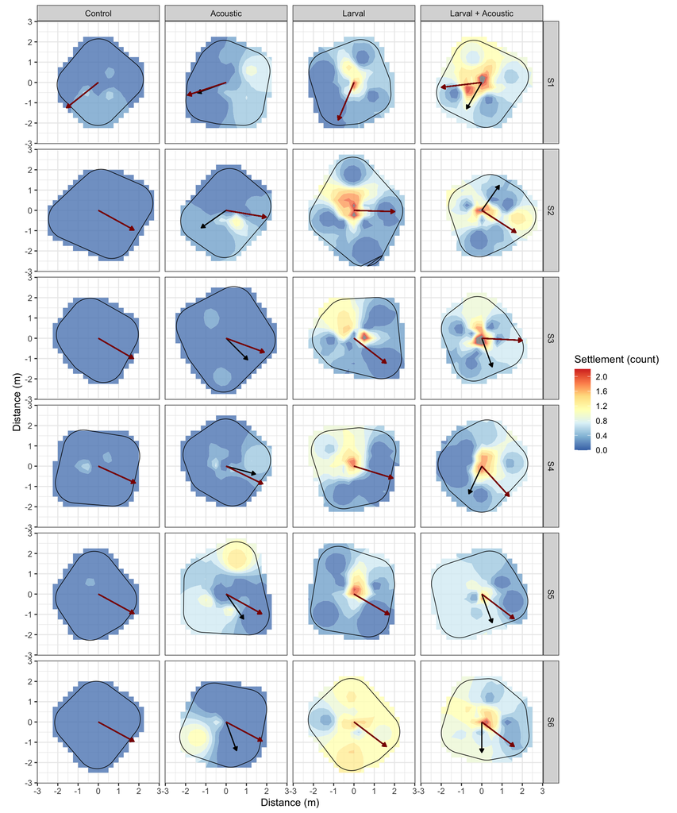

```r
ggplot() +
  geom_contour_filled(
    data = df_pairwise |>  dplyr::mutate(
    treatment = forcats::fct_recode(
      treatment,
      "Control"            = "control",
      "Acoustic"           = "acoustic",
      "Larval"             = "larval",
      "Larval + Acoustic"  = "larvalacoustic"
    )
  ),
    aes(x, y, z = value, fill = after_stat(level_mid)),
    alpha = 0.8
  ) +
  geom_polygon(
    data = group_poly_df |>
      dplyr::mutate(
        treatment = forcats::fct_recode(
          treatment,
          "Control"            = "control",
          "Acoustic"           = "acoustic",
          "Larval"             = "larval",
          "Larval + Acoustic"  = "larvalacoustic"
        )
      ),
    aes(x = X, y = Y, group = L1),
    fill = NA, color = "black", linewidth = 0.3
  ) +
  coord_equal() +
  xlim(-2.75, 2.75) +
  ylim(-2.75, 2.75) +
  #scale_fill_distiller(palette = "Spectral", name = "(log10+1) settlers") +
  facet_grid(site ~ treatment) +
  theme_bw() +
  xlab("Distance (m)") +
  ylab("Distance (m)") +
  scale_fill_distiller(
    palette = "RdYlBu", direction = -1,
    name = "Settlement (count)",
    limits = c(0, 2.2),
    breaks = seq(0, 2.2, 0.4)
    #labels = function(b) scales::number(10^b, accuracy = 1)
  ) +
    geom_segment(
    data = dir_arrows |>
      dplyr::mutate(
        treatment = forcats::fct_recode(
          treatment,
          "Control"            = "control",
          "Acoustic"           = "acoustic",
          "Larval"             = "larval",
          "Larval + Acoustic"  = "larvalacoustic"
        )
      ),
    aes(x = x0, y = y0, xend = x1*1.5, yend = y1*1.5),
    arrow = arrow(length = unit(0.15, "cm"), type = "closed"),
    color = "black",
    linewidth = 0.6
  ) +
  geom_segment(
    data = flow_arrows |>
      dplyr::mutate(
        treatment = forcats::fct_recode(
          treatment,
          "Control"            = "control",
          "Acoustic"           = "acoustic",
          "Larval"             = "larval",
          "Larval + Acoustic"  = "larvalacoustic"
        )
      ),
    aes(x = x0, y = y0, xend = x1, yend = y1),
    arrow = arrow(length = unit(0.15, "cm"), type = "closed"),
    color = "darkred",
    linewidth = 0.6,
    linetype = "solid"
  )
```